# Datos suicidio

Juncal Arija, Naroa Supervia, Leire Tapia

2025-11-24

# 1 **INTRODUCCIÓN**

El **suicidio** es una de las principales causas de muerte no natural a nivel global y constituye un importante problema de salud pública en España.

En este seminario, nos proponemos estudiar como ha evolucionado el suicidio en España en los ultimos años utilizando datos oficiales del INE para explorar las diferencias entre el sexo la edad y el territorio, entre otras, con la intención de entender mejor qué tendencias aparecen en los datos y que factores podrían estar influyendo en estas variaciones.

# 2 **OBJETIVOS**

1. Describir la distribución del suicidio por sexo en España.
2. Analizar las diferencias entre provincias.
3. Estudiar la influencia del grupo de edad en la cantidad de suicidios.
4. Unificar los datos CSV y JSON para obtener una vista más completa y comparar la relación y fiabilidad de los datos.
5. Analizar la frecha de género

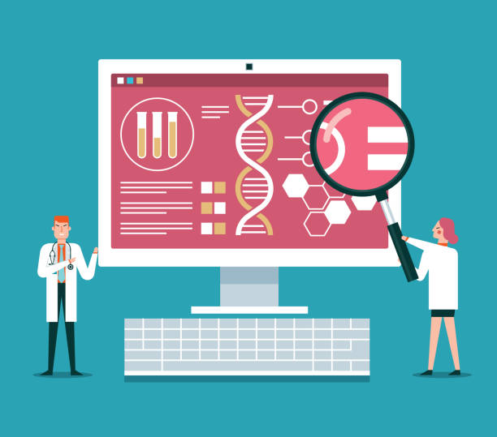

# 3 **PAQUETES UTILIZADOS**

Para poder utilizar nuestros conjuntos de datos es necesario importar las siguientes librerias y paquetes:

```r
# Datos con formato .csv:
library(readr)

#Datos con formato .json:
library(tidyverse)
library(rjson)
library(jsonlite)
library(tidyjson)

#Visualizacion resultados:
library(DT)
library(ggplot2)
library(gifski)
library(gganimate)
library(plotly)
library(dplyr)
library(mapSpain)
library(knitr) # librería para tablas
library(stringr)
library(scales)
library(purrr)
library(tidyr)
```

# 4 **DESARROLLO Y RESULTADOS**

Una vez cargadas las librerias importamos los datos.

## 4.1 OBTENCIÓN DE LOS DATOS

Para este trabajo se han utilizado dos conjuntos de datos procedentes del Instituto Nacional de Estadísitca (INE), a través de sus estadísticas oficiales sobre defunciones según causa de muerte. Ambas fuentes se han descargado directamente desde la herramienta de consulta del INE y contienen información actualizada y validada por el organismo.

- **provincias_sexo.csv**: Este archivo recoge la tasa de suicidios por cada 100.000 habitantes en Esapaña, desglosada por: provincia, sexo (total, hombes, mujeres) y año (2021, 2022 y 2023). Cada fila representa la tasa correspondiente a un territorio y un sexo concreto en un año determinado. Estos valores provienen directamente el INE y reflejan las tasas oficiales calculadas del instituto, basadas en la población residente de cada año. Este archivo le hemos utilizado para:
  - Analizar la evolución reciente (2021 - 2023)
  - Las diferencias entre sexos
  - Las variaciones territoriales entre provincias.
- **suicidio_Edad-Sexo.json**: Este JSON contiene el número absoluto de suicidios registrados a nivel nacional en el año 2022. Está desglosado por grupo de edad y por sexo. La estructura del Json incluye:
  - Un campo MetaData, donde se especifíca el sexo y el grupo de edad.
  - Un campo Data, donde aparece el valor numérico de suicidios en ese grupo. Estos datos también han sido descargados del INE y corresponden al mismo sistema estadístico, pero en este caso sin convertirlos en tasas, es decir, son numéros absolutos de casos, no tasas de población. Este archivo se ha empleado para:
  - Calcular los suicidios totales por sexo
  - Relacionar los valores con la población para obtener tasas a medida
  - Analizar diferencias entre grupos de edad

En resumen, el CSV ofrece tasas por provincia, sexo y año, mientras que el JSON proporciona números absolutos por edad y sexo a nivel nacional. Esta combinación permite un análisis estadístico completo tanto a nivel territorial como demográfico.

## 4.2 IMPORTACIÓN DE LOS DATOS

### 4.2.1 **Importación de datos CSV**

En algunos de nuestros archivos csv, es necesario especificar el tipo de codificación que tienen, para que R pueda leer correctamente los caracteres especiales como *tildes* o *ñ*.

```r
provincias <- read_delim("INPUT/DATA/provincias_sexo.csv",
                         delim = ";",
                         trim_ws = TRUE,
                         col_types = cols(.default = "c"))
head(provincias)
```

| Provincias | Sexo | Periodo | Total |
| --- | --- | --- | --- |
| Nacional | Total | 2023 | 8,512 |
| Nacional | Total | 2022 | 8,846 |
| Nacional | Total | 2021 | 8,45 |
| Nacional | Hombres | 2023 | 12,846 |
| Nacional | Hombres | 2022 | 13,343 |
| Nacional | Hombres | 2021 | 12,833 |

### 4.2.2 **Importación del JSON**

```r
#Ruta al archivo JSON
suicidios_json <- jsonlite::fromJSON("INPUT/DATA/Suicidio_Edad-Sexo.json", flatten=TRUE)

suicidios_df <- as.data.frame(suicidios_json)

# Mostrar las primeras filas
head(suicidios_df)
```

|  | Nombre | MetaData | Data |
| --- | --- | --- | --- |
| 1 | Todas las edades, Ambos sexos |  |  |
| 2 | Todas las edades, Hombres |  |  |
| 3 | Todas las edades, Mujeres |  |  |
| 4 | Menores de 15 años, Ambos sexos |  |  |
| 5 | Menores de 15 años, Hombres |  |  |
| 6 | Menores de 15 años, Mujeres |  |  |

## 4.3 FILTRADO Y PREPARACIÓN DE LOS DATOS

Los datos han sido filtrados y preparados para asegurar la coherencia entre las fuentes.

### 4.3.1 **Convertir la columna ‘Total’ del CSV de texto a número**

```r
provincias <- provincias %>%
  mutate(
    #Cambiamos total a numerico y la coma a punto
    Total = as.numeric(gsub(",", ".", Total)),
    # Convertimos'Periodo' a número también
    Periodo = as.numeric(Periodo)
  )

# Ahora creamos el dataframe filtrado
Suicidios_CSV_filtrado <- provincias %>%
  filter(Sexo != "Total",
         Provincias != "Nacional")

# Verificamos: Total debe ser <dbl> (número real con decimales)
head(Suicidios_CSV_filtrado)
```

| Provincias | Sexo | Periodo | Total |
| --- | --- | --- | --- |
| 01 Araba/Álava | Hombres | 2023 | 10.835 |
| 01 Araba/Álava | Hombres | 2022 | 13.939 |
| 01 Araba/Álava | Hombres | 2021 | 10.963 |
| 01 Araba/Álava | Mujeres | 2023 | 4.086 |
| 01 Araba/Álava | Mujeres | 2022 | 4.703 |
| 01 Araba/Álava | Mujeres | 2021 | 5.323 |

### 4.3.2 **Eliminar “total” en sexo**

Para así comparar hombres vs mujeres

```r
provincias_filtrado <- provincias %>%
  filter(Sexo != "Total")

# Revisar resultado
head(provincias_filtrado)
```

| Provincias | Sexo | Periodo | Total |
| --- | --- | --- | --- |
| Nacional | Hombres | 2023 | 12.846 |
| Nacional | Hombres | 2022 | 13.343 |
| Nacional | Hombres | 2021 | 12.833 |
| Nacional | Mujeres | 2023 | 4.348 |
| Nacional | Mujeres | 2022 | 4.520 |
| Nacional | Mujeres | 2021 | 4.230 |

### 4.3.3 **El JSON:separar edad y sexo**

Extraer: - Lista de edades - Lista de sexos - Valor

```r
Suicidios_Edad <- as_tibble(suicidios_json) %>%

  mutate(Valor = map_dbl(Data, ~ .x$Valor[1])) %>%

  select(ID_Fila = Nombre, Valor, MetaData) %>%

  unnest(MetaData) %>%

  # Selecciona solo las columnas que necesitamos para pivotar
  select(ID_Fila, Valor, T3_Variable, Nombre) %>%

  # Pivotar usando el ID_Fila
  pivot_wider(names_from = T3_Variable, values_from = Nombre) %>%

  # Filtrar los totales
  filter(sexo != "Ambos sexos",
         edad != "Todas las edades") %>%

  # Quitar la columna de ID, ya no la necesitamos
  select(edad, sexo, Valor)

# Esta tabla ya no debería tener NAs en 'edad' o 'sexo'
print("Datos JSON (versión final) listos:")
```

```
## [1] "Datos JSON (versión final) listos:"
```

```r
head(Suicidios_Edad)
```

| edad | sexo | Valor |
| --- | --- | --- |
| Menores de 15 años | Hombres | 9 |
| Menores de 15 años | Mujeres | 3 |
| De 15 a 29 años | Hombres | 224 |
| De 15 a 29 años | Mujeres | 117 |
| De 30 a 39 años | Hombres | 336 |
| De 30 a 39 años | Mujeres | 100 |

## 4.4 RESULTADOS

Estudio de los datos y gráficos

### 4.4.1 **Suicidio por sexo a nivel nacional**

Usando los datos del JSON, a partir de la tabla Suicidios_Edad (con las columnas sexo, edad y valor), agrupamos los datos que tengan el mismo valor en la columna sexo (hombres/mujeres) y para cada grupo hemos calculado la suma total de la columna valor. Como resultado obtenemos un nuevo tibble de 2 filas (una por sexo), con las columnas sexo y total. Con el nuevo tibble creamos un gráfico de barras.

```r
# Sumar los valores por sexo
suicidio_sexo_nacional <- Suicidios_Edad %>%
  group_by(sexo) %>%
  summarise(Total = sum(Valor, na.rm = TRUE))

# Revisar tabla
print(suicidio_sexo_nacional)
```

```
## # A tibble: 2 × 2
##   sexo    Total
##   <chr>   <dbl>
## 1 Hombres  3126
## 2 Mujeres  1101
```

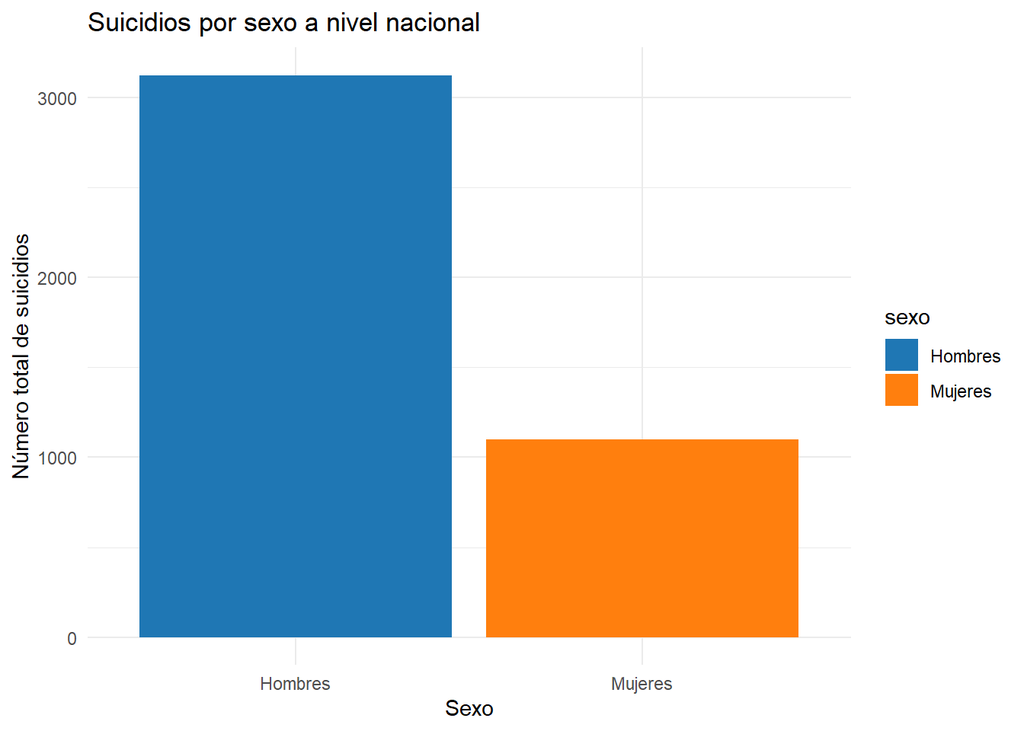

```r
# GRAFICO DE BARRAS (suicidios por sexo a nivel nacional)
ggplot(suicidio_sexo_nacional, aes(x = sexo, y = Total, fill = sexo)) +
  geom_bar(stat = "identity") +
  labs(
    title = "Suicidios por sexo a nivel nacional",
    x = "Sexo",
    y = "Número total de suicidios"
  ) +
  scale_fill_manual(values = c("Hombres" = "#1f77b4", "Mujeres" = "#ff7f0e")) +
  theme_minimal()
```

Podemos representar los datos anteriores en un gráfico circular para obtener otra visualización.

```r
# 1. Filtrar datos a nivel nacional (ya que JSON tiene solo sexo y edad, sumamos por sexo)
nacional_sexo <- Suicidios_Edad %>%
  group_by(sexo) %>%
  summarise(Total = sum(Valor))

print(nacional_sexo) #visualizamos el nuevo tibble
```

```
## # A tibble: 2 × 2
##   sexo    Total
##   <chr>   <dbl>
## 1 Hombres  3126
## 2 Mujeres  1101
```

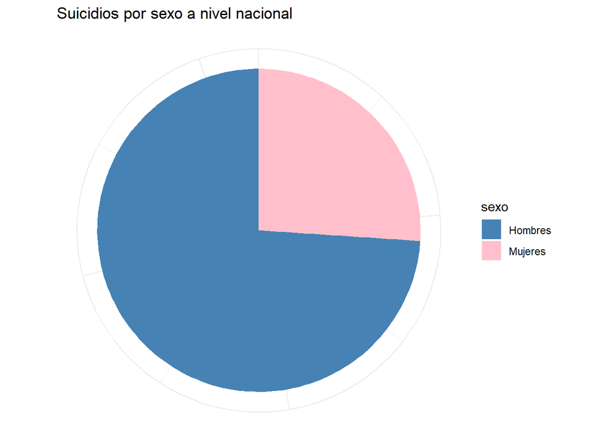

```r
#GRÁFICO CIRCULAR
ggplot(nacional_sexo, aes(x = "", y = Total, fill = sexo)) +
  geom_bar(stat = "identity", width = 1) +   # barra para convertir a circular
  coord_polar(theta = "y") +                 # transforma a circular
  labs(title = "Suicidios por sexo a nivel nacional") +
  theme_minimal() +
  theme(axis.title = element_blank(),
        axis.text = element_blank(),
        axis.ticks = element_blank()) +
  scale_fill_manual(values = c("Hombres" = "steelblue", "Mujeres" = "pink"))
```

```r
datatable(provincias,
          caption = 'Tabla 1: Tasas de suicidio por provincia y sexo',
          options = list(pageLength = 10, autoWidth = TRUE, scrollX = TRUE))
```

|  | Provincias | Sexo | Periodo | Total |
| --- | --- | --- | --- | --- |
| 1 | Nacional | Total | 2023 | 8.512 |
| 2 | Nacional | Total | 2022 | 8.846 |
| 3 | Nacional | Total | 2021 | 8.45 |
| 4 | Nacional | Hombres | 2023 | 12.846 |
| 5 | Nacional | Hombres | 2022 | 13.343 |
| 6 | Nacional | Hombres | 2021 | 12.833 |
| 7 | Nacional | Mujeres | 2023 | 4.348 |
| 8 | Nacional | Mujeres | 2022 | 4.52 |
| 9 | Nacional | Mujeres | 2021 | 4.23 |
| 10 | 01 Araba/Álava | Total | 2023 | 7.408 |

[output cut: 467 more lines]

Los resultados de los gráficos muestra que los hombres presentan claramente un mayor número de suicidios. Podemos decir que los hombres representan aproximadamente el 75% de los suicidios a nivel nacional, mientras que las mujeres el 25%.

Este patrón puede estar asociado a factores socioculturales, diferencias en métodos utilizados, menor búsqueda de ayuda por parte de los hombres o barreras sociales relaccionadas con la salud mental.

### 4.4.2 **Suicidio por provincia**

```r
options(scipen = 999)
# Filtrado
Suicidios_CSV_filtrado_FINAL <- provincias %>%
  filter(Sexo != "Total",
         Provincias != "Nacional") %>%
  mutate(
    # Eliminar código numérico inicial
    Nombre_Limpio = str_remove(Provincias, "^\\d{1,2}\\s"),

    # Normalización de nombres
    Nombre_Final = case_when(
        str_detect(Nombre_Limpio, "Alacant/Alicante") ~ "Alicante",
        str_detect(Nombre_Limpio, "Castelló/Castellón") ~ "Castellón",
        str_detect(Nombre_Limpio, "València/Valencia") ~ "Valencia",
        str_detect(Nombre_Limpio, "Araba/Álava") ~ "Álava",
        str_detect(Nombre_Limpio, "Balears, Illes") ~ "Baleares",
        str_detect(Nombre_Limpio, "A Coruña") ~ "A Coruña",
        # Convertir el resto a formato Título
        TRUE ~ str_to_title(tolower(Nombre_Limpio))
    )
  )

# Creación del gráfico estático
p <- ggplot(Suicidios_CSV_filtrado_FINAL, aes(x = Sexo, y = Total, color = Sexo)) +
  geom_point(size = 3, alpha = 0.8) +
  facet_wrap(~Nombre_Final, ncol = 6) +
  labs(
    title = "Tasa de Suicidio por Provincia y Sexo (2021-2023)",
    subtitle = "Tasa por 100.000 habitantes. Se excluye el dato nacional.",
    x = "Sexo",
    y = "Tasa Total (x 100.000 hab.)"
  ) +
theme_minimal() +
theme(
  axis.text.x = element_blank(),
  axis.ticks.x = element_blank(),
  strip.text = element_text(size = 7), # Tamaño de nombres de provincias
  legend.position = "bottom",          # Leyenda abajo
  panel.grid.major.x = element_blank()
) +
  # Formato de ejes con coma decimal
  scale_y_continuous(labels = label_number(big.mark = ".", decimal.mark = ","))

# Conversión a interactivo y ajuste final
p_plotly <- ggplotly(p)

p_plotly <- p_plotly %>%
  layout(yaxis = list(tickformat = ",.1f",
                      hoverformat = ",.3f"
                      ))

p_plotly
```

[interactive chart not shown]

El gráfico muestra la tasa de suicidios por cada 100.000 habitantes en todas las provincias españolas entre 2021 y 2023, y además separa los datos por sexo (hombres en rojo y mujeres en azul), lo que permite ver tanto las diferencias entre provincias como la brecha entre hombres y mujeres.

Al observar el gráfico podemos ver que existe una diferencia muy grande entre hombres y mujeres, y que las tasas cambian mucho según la provincia, sobre todo en los hombres.

En cuanto a la diferencia entre sexos, las mujeres tienen tasas bastante bajas y estables, normalmente entre 5 y 7 casos por cada 100.000 habitantes, mientras que los hombres, presentan valores mucho más altos y con más variación, llegando incluso a triplicar o cuadruplicar las cifras femeninas en la mayoría de los territorios.

También se ven diferencias claras entre provincias, especialmente entre los hombres. Las tasas masculinas más altas aparecen normalmente en provincias como Asturias, Lugo, Ourense o Zamora que superan o se acercan a los 20 casos por cada 100.000 habitantes, y en otras provincias, como Madrid, Guadalajara o Valladolid, las tasas son más bajas (alrededor de 10-12), aunque la diferencia respecto a las mujeres sigue existiendo.

### 4.4.3 **Mapa interactivo de suicidio por provincia**

```r
# Lectura y limpieza inicial de datos
provincias_raw <- read_delim("INPUT/DATA/provincias_sexo.csv",
                             delim = ";", trim_ws = TRUE,
                             locale = locale(encoding = "ISO-8859-1"),
                             show_col_types = FALSE)

provincias_raw$Total <- as.numeric(gsub(",", ".", provincias_raw$Total))
provincias_raw$Periodo <- as.numeric(provincias_raw$Periodo)

# Agregación y preparación de códigos
datos_mapa <- provincias_raw %>%
  filter(Sexo != "Total", Provincias != "Nacional") %>%
  mutate(
    # Extraemos los dos primeros dígitos para obtener el código INE
    cod_join = str_sub(Provincias, 1, 2)
  ) %>%
  group_by(cod_join) %>%
  summarise(
    Tasa_Media = mean(Total, na.rm = TRUE),
    Nombre_Provincia_Original = first(Provincias),
    .groups = 'drop'
  )

# Descargar geometría y unir datos
mapa_provincias <- esp_get_prov_siane(resolution = 10)

mapa_datos <- mapa_provincias %>%
  mutate(cpro_join = as.character(cpro)) %>%
  left_join(datos_mapa, by = c("cpro_join" = "cod_join"))

# Crear el gráfico interactivo
p_mapa <- ggplot(mapa_datos) +
  geom_sf(aes(fill = Tasa_Media,
              text = paste("Provincia:", str_remove(Nombre_Provincia_Original, "^\\d{1,2}\\s"),
                           "<br>Tasa Media (x 100k):", format(Tasa_Media, big.mark = ".", decimal.mark = ","))
              )) +
  scale_fill_gradient(
    low = "#fef0d9",
    high = "#b30000",
    name = "Tasa Media (x 100k hab.)",
    labels = label_number(big.mark = ".", decimal.mark = ",")
  ) +
  labs(
    title = "Tasa Media de Suicidio por Provincia (2021-2023)",
    caption = "Fuente: INE."
  ) +
  theme_void() +
  theme(legend.position = "bottom")

# Convertir a Plotly para interactividad
ggplotly(p_mapa, tooltip = "text")
```

[interactive chart not shown]

Este mapa muestra cómo se distribuyen las tasas medias de suicidio por cada 100.000 habitantes en España entre 2021 y 2023, haciendo media con hombres y mujeres. Los colores ayudan a identificar rápidamente las zonas con más o menos incidencia, ya que los tonos claros representan tasas bajas y los tonos rojos más intensos indican tasas altas.

Al analizar el mapa, podemos ver que las tasas más altas se concentran sobre todo en el noroeste, en zonas de Galicia, Zamora y León, especialmente Lugo aparece con el tono más oscuro, lo que indica que están muy por encima de la media nacional, con valores que rondan o superan los 12-14 casos por cada 100.000 habitantes, siendo esta la provincia con mayor tasa de suicidios.

Por el contrario, en zonas del centro como Madrid, tienen tasas bastante más bajas, alrededor de 4 a 8 casos.

### 4.4.4 **Suicidio por edad (JSON)**

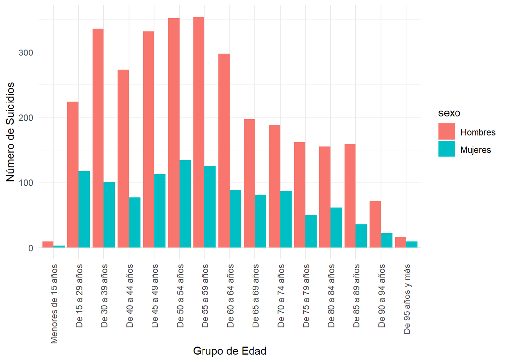

```r
# 1. Definimos el orden correcto cronológicamente
orden_correcto <- c(
  "Menores de 15 años",
  "De 15 a 29 años",
  "De 30 a 39 años",
  "De 40 a 44 años",
  "De 45 a 49 años",
  "De 50 a 54 años",
  "De 55 a 59 años",
  "De 60 a 64 años",
  "De 65 a 69 años",
  "De 70 a 74 años",
  "De 75 a 79 años",
  "De 80 a 84 años",
  "De 85 a 89 años",
  "De 90 a 94 años",
  "De 95 años y más"
)

Suicidios_Edad$edad <- factor(Suicidios_Edad$edad, levels = orden_correcto)

ggplot(Suicidios_Edad, aes(x = edad, y = Valor, fill = sexo)) +
  geom_bar(stat = "identity", position = "dodge") +
  theme_minimal() +
  theme(axis.text.x = element_text(angle = 90, vjust = 0.5, hjust = 1)) +
  labs(x = "Grupo de Edad", y = "Número de Suicidios")
```

Este gráfico de barras muestra cuántos suicidios hubo en total según los diferentes grupos de edad, separando también por sexo (hombres en rojo y mujeres en azul). A diferencia de los mapas o las tasas por provincias, aquí no hablamos de proporciones, sino de números absolutos. Eso permite ver claramente en qué etapas de la vida se concentran más casos.

A partir del gráfico se pueden destacar dos ideas principales, la brecha entre hombres y mujeres aparece en todas las edades, y los suicidios se concentran sobre todo en la mediana edad.

Las edades comprendidas entre los 40 y los 59 años son las que acumulan más casos tanto en hombres como en mujeres. En especial, los grupos de 50-54 y 55-59 años son los que muestran los valores más altos.

En cambio, las cifras descienden bastante en los grupos de mayor edad de 90 a +95 años y son muy bajas entre los menores de 15.

### 4.4.5 **Union CSV + JSON**

Como el CSV tiene los datos en referencia a 100.000 habitantes, vamos a hacer lo mismo con el JSON y así podremos compararlos.

**1. Creación de la tabla de referencia**

En este paso,creamos una tabla de referencia de población, para ello usamos los datos oficiales totales de hombres y mujeres encontrados en INE. En esta nueva tabla la columna sexo será clave para unirla posteriormente con nuestros datos.

```r
poblacion_ref <- data.frame(
  sexo = c("Hombres", "Mujeres"),
  Poblacion_Nacional = c(23265381, 24210039)
)

print(poblacion_ref)
```

```
##      sexo Poblacion_Nacional
## 1 Hombres           23265381
## 2 Mujeres           24210039
```

**2. Unión y cálculo de tasas**

Unimos la nueva tabla creada con la población de referencia al JSON y calculamos las tasas. Left_join: Esta función incorpora los datos de la tabla calculada anteriormente (poblacion_ref) a nuestra tabla principal (suicidios_edad). Busca coindidencias en la columna comun ‘sexo’ y añade la columna ‘Poblacion_Nacional’ a cada fila correspondiente. mutate(Tasa_aportacion…): crea una nueva columna calculada que nos da la tasa específica de ese grupo de edad. Nos dice cuantos suicidios aporta ese rango de edad para cada 100.000 habitantes de ese sexo.

```r
# Partimos de la tabla 'Suicidios_Edad' que creamos al procesar el JSON
Suicidios_Con_Tasas <- Suicidios_Edad %>%
  # Unimos con nuestra tabla de población manual mediante un left_join
  left_join(poblacion_ref, by = "sexo") %>%
  # Calculamos la tasa por 100.000 habitantes
  mutate(Tasa_Aportacion = (Valor / Poblacion_Nacional) * 100000)

# Visualizamos la tabla resultante
head(Suicidios_Con_Tasas)
```

| edad | sexo | Valor | Poblacion_Nacional | Tasa_Aportacion |
| --- | --- | --- | --- | --- |
| Menores de 15 años | Hombres | 9 | 23265381 | 0.03868409 |
| Menores de 15 años | Mujeres | 3 | 24210039 | 0.01239155 |
| De 15 a 29 años | Hombres | 224 | 23265381 | 0.96280392 |
| De 15 a 29 años | Mujeres | 117 | 24210039 | 0.48327060 |
| De 30 a 39 años | Hombres | 336 | 23265381 | 1.44420588 |
| De 30 a 39 años | Mujeres | 100 | 24210039 | 0.41305179 |

**3. Gráfico comparativo**

Generamos un gráfico de barras para visualizar las tasas calculadas para cada grupo de edad, confirmando que se corresponde con la misma forma del anterior gráfico, pero esta vez, calculado con la tasa por cada 100.000 habitantes del mismo sexo.

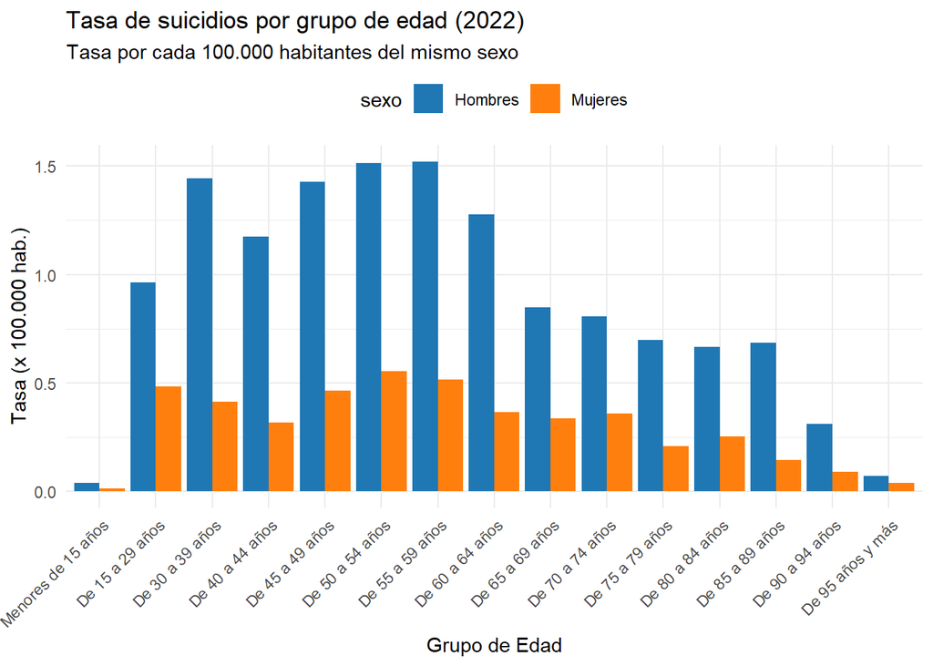

```r
#En el eje X ponemos los grupos de edad y en el eje Y la tasa calculada.
#Con 'dodge', las barras de hombres y mujeres se colocan una al lado de otra, evitando solapamientos.
ggplot(Suicidios_Con_Tasas, aes(x = edad, y = Tasa_Aportacion, fill = sexo)) +
  geom_bar(stat = "identity", position = "dodge") +
  scale_fill_manual(values = c("Hombres" = "#1f77b4", "Mujeres" = "#ff7f0e")) +
  labs(
    title = "Tasa de suicidios por grupo de edad (2022)",
    subtitle = "Tasa por cada 100.000 habitantes del mismo sexo",
    y = "Tasa (x 100.000 hab.)",
    x = "Grupo de Edad"
  ) +
  theme_minimal() +
  #rotamos 45 grados las etiquetas del eje X porque los nombres de los grupos de edad son largos y si no se solaparían.
  theme(
    axis.text.x = element_text(angle = 45, hjust = 1),
    legend.position = "top"
  )
```

**4. Validación (unión)**

Este es el paso de control de calidad para demostrar que las fuentes (CSV y JSON) son coherentes entre sí. - validacion_json: Agrupamos los datos del JSON por sexo y sumamos todas las tasas parciales de los grupos de edad. La suma de las partes debe dar el total nacional. - validacion_csv: Filtramos para quedarnos solo con el dato nacional de 2022 (ya que el JSON se corresponde también con dicho año) - left_join: Une los dos resultados en una sola tabla (comparativa_fuentes). Si los números coindicen, hemos demostrado que la integración de los datos es correcta.

```r
# 1. Calculamos la tasa total del JSON
validacion_json <- Suicidios_Con_Tasas %>%
  group_by(sexo) %>%
  summarise(Tasa_Calculada_JSON = sum(Tasa_Aportacion))

# 2. Sacamos la tasa del CSV
validacion_csv <- provincias %>%
  filter(Provincias == "Nacional", Periodo == 2022, Sexo != "Total") %>%
  select(Sexo, Tasa_Oficial_CSV = Total)

# 3. Unimos ambas tablas
comparativa_fuentes <- left_join(validacion_json, validacion_csv, by = c("sexo" = "Sexo"))

print(comparativa_fuentes)
```

```
## # A tibble: 2 × 3
##   sexo    Tasa_Calculada_JSON Tasa_Oficial_CSV
##   <chr>                 <dbl>            <dbl>
## 1 Hombres               13.4             13.3
## 2 Mujeres                4.55             4.52
```

**5- Gráfico comparando CSV y JSON**

Representamos gráficamente la validación anterior. El siguiente gráfico nos permite confirmar visualmente la cosistencia entre nuestras dos fuentes de datos. Si las barras de cada par tienen la misma altura, significa que la integración de los datos absolutos del JSON con las tasas oficiales del CSV se corresponden.

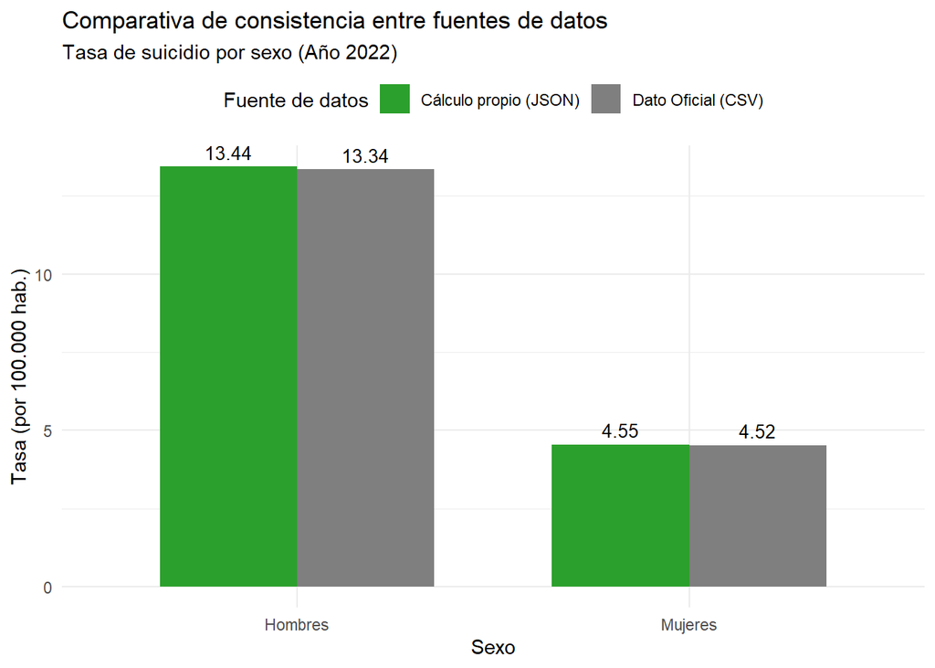

```r
# 1. Preparamos los datos

# A) Datos del JSON (Calculados)
datos_json <- comparativa_fuentes %>%
  select(sexo, Tasa = Tasa_Calculada_JSON) %>%
  mutate(
    Fuente = "Cálculo propio (JSON)",
    Tasa = as.numeric(Tasa) # Aseguramos que sea número
  )

# B) Datos del CSV
datos_csv <- comparativa_fuentes %>%
  select(sexo, Tasa = Tasa_Oficial_CSV) %>%
  mutate(
    Fuente = "Dato Oficial (CSV)",
    # Pasamos a texto -> cambiamos coma por punto -> pasamos a número
    Tasa = as.numeric(gsub(",", ".", as.character(Tasa)))
  )

# C) Unimos las dos tablas (ahora sí, ambas son numéricas)
datos_grafico <- bind_rows(datos_json, datos_csv)

# 2. Creamos el gráfico de barras agrupadas
ggplot(datos_grafico, aes(x = sexo, y = Tasa, fill = Fuente)) +
  geom_bar(stat = "identity", position = "dodge", width = 0.7) +
  geom_text(aes(label = round(Tasa, 2)),
            position = position_dodge(width = 0.7),
            vjust = -0.5, size = 3.5) +
  scale_fill_manual(values = c("Cálculo propio (JSON)" = "#2ca02c", "Dato Oficial (CSV)" = "#7f7f7f")) +
  labs(
    title = "Comparativa de consistencia entre fuentes de datos",
    subtitle = "Tasa de suicidio por sexo (Año 2022)",
    y = "Tasa (por 100.000 hab.)",
    x = "Sexo",
    fill = "Fuente de datos"
  ) +
  theme_minimal() +
  theme(legend.position = "top")
```

El gráfico de barras agrupadas compara las tasas de suicidio por sexo obtenidas de dos formas distintas: - Dato oficial (CSV): La tasa publicada directamente por el INE - Cálculo propio (JSON): La tasa que hemos calculado nosotros mismos sumando los suicidios absolutos por edad del JSON y dividiéndolos por la población oficial de España.

Como se puede observar, las barras verdes y las grises son prácticamente idénticas tanto para hombres como para mujeres. Esta coincidencia nos permite afirmar: - La validación metodológica, nuestro procedimiento para unir las bases de datos y calcular las tasas por edad ha sido correcto. - La consistencia de los datos, confirmarmos que ambas fuentes de datos del INE son coherentes entre sí, asegurando que los análisis detallados que hemos realizado anteriormente son representativos y fiables.

### 4.4.6 **Análisis brecha de género**

Para finalizar, calculamos cuántos hombres se suicidan por cada mujer en cada grupo de edad. Este gráfico responde a la pregunta: “¿Por cada mujer que se suicida en este grupo de edad, cuántos hombres lo hacen?. Un valor de 1 significa igualdad, un valor de 3 significa que hay 3 veces más suicidios masculinos en dicho grupo.

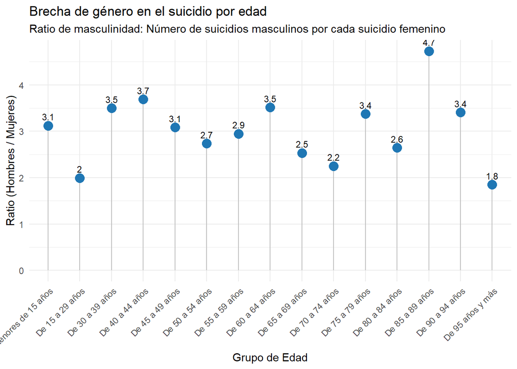

```r
# 1. Preparamos los datos: Pivotamos para tener Hombres y Mujeres en columnas
brecha_genero <- Suicidios_Con_Tasas %>%
  select(edad, sexo, Tasa_Aportacion) %>%
  pivot_wider(names_from = sexo, values_from = Tasa_Aportacion) %>%
  # Calculamos el Ratio (Cuántos hombres por cada mujer)
  mutate(Ratio_H_M = Hombres / Mujeres)

# 2. Gráfico para visualizar la diferencia
ggplot(brecha_genero, aes(x = edad, y = Ratio_H_M)) +
  # Línea vertical desde 0 hasta el punto
  geom_segment(aes(x = edad, xend = edad, y = 0, yend = Ratio_H_M), color = "grey") +
  # Punto en el valor del ratio
  geom_point(size = 4, color = "#1f77b4") +
  # Texto con el valor exacto
  geom_text(aes(label = round(Ratio_H_M, 1)), vjust = -0.8, size = 3) +
  labs(
    title = "Brecha de género en el suicidio por edad",
    subtitle = "Ratio de masculinidad: Número de suicidios masculinos por cada suicidio femenino",
    y = "Ratio (Hombres / Mujeres)",
    x = "Grupo de Edad"
  ) +
  theme_minimal() +
  theme(axis.text.x = element_text(angle = 45, hjust = 1))
```

Este análisis revela que el suicidio es un fenómeno muy masculinizado en todos los grupos de edad (todos los ratios son superiores a 1). Sin embargo, observamos que la brecha no es constante, se dispara en el grupo de 85 a 89 años, donde hay casi 5 hombres por cada mujer.

# 5 **CONCLUSIONES**

Tras el análisis comparativo de las tasas de suicidio en España utilizando datos oficiales del INE, podemos extraer las siguientes conclsiones principales: Se ve claramente que el suicidio en España no afecta igual a todo el mundo. Por un lado, hay una diferencia muy marcada entre hombres y mujeres, ya que los hombres siempre presentan cifras más altas, tanto en tasas por 100.000 habitantes como en números absolutos. Por otro lado, tampoco todas las provincias se comportan igual, en zonas del noroeste es donde aparecen las tasas más elevadas, mientras que en el centro y el sur los valores son bastante más bajos en comparación.

Si miramos por edad, los casos se concentran sobre todo en la mediana edad, especialmente entre los 40 y los 59 años. En cambio, en los grupos más jóvenes y más mayores los valores bajan bastante.

Además, los datos del CSV y del JSON encajan bien entre sí, lo que da más confianza en los resultados del análisis. Gracias a esto, podemos entender mejor un problema tan complejo y ver que influyen muchos factores como el lugar donde se vive, la edad y el sexo.

Este análisis de datos destaca la necesidad de estrategías de prevención dirigidas específicamente a los grupos de mayor riesgo identificados. Que en base a este estudio serían los hombres de Lugo que están en la mediana edad.

# 6 **REFERENCIAS**

https://datos.gob.es/es/

https://ine.es/